# FINAL PROJECT

VAIBHAV AMITBHAI PATEL

12-08-2021

| **IMPORT LIBRARY** |
| --- |

| **QUESTIONS & ANSWERS** |
| --- |

| **Question 1: What is the highest value of average level of glucose in health care dataset stroke.?** |
| --- |

```
## Rows: 5,110
## Columns: 12
## Groups: gender [3]
## $ id                <int> 69112, 22440, 26267, 10995, 27626, 13155, 71279, 500~
## $ gender            <chr> "Male", "Female", "Female", "Male", "Female", "Femal~
## $ age               <dbl> 68, 49, 76, 76, 60, 67, 71, 62, 67, 80, 28, 48, 39, ~
## $ hypertension      <int> 1, 0, 0, 1, 0, 1, 0, 1, 0, 0, 0, 0, 0, 1, 0, 1, 0, 0~
## $ heart_disease     <int> 1, 0, 0, 0, 0, 0, 0, 0, 0, 0, 0, 0, 0, 1, 1, 0, 0, 0~
## $ ever_married      <chr> "Yes", "Yes", "Yes", "Yes", "No", "Yes", "Yes", "Yes~
## $ work_type         <chr> "Private", "Private", "Self-employed", "Private", "G~
## $ Residence_type    <chr> "Rural", "Urban", "Urban", "Rural", "Rural", "Rural"~
## $ avg_glucose_level <dbl> 271.74, 267.76, 267.61, 267.60, 266.59, 263.56, 263.~
## $ bmi               <chr> "31.1", "29.3", "27.9", "30.5", "25.5", "26.3", "38.~
## $ smoking_status    <chr> "smokes", "formerly smoked", "smokes", "never smoked~
## $ stroke            <int> 1, 0, 0, 0, 0, 0, 1, 0, 0, 1, 0, 0, 0, 0, 0, 0, 0, 0~
```

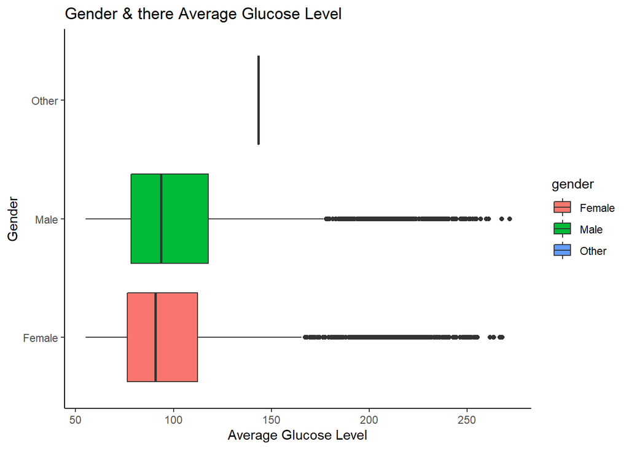

*ANS:- The above analysis shows that Male people are highest in number of Average Glucose Level rather than Female & Other gender type.*

| **Question 2: Create a plot of single categorical variable.?** |
| --- |

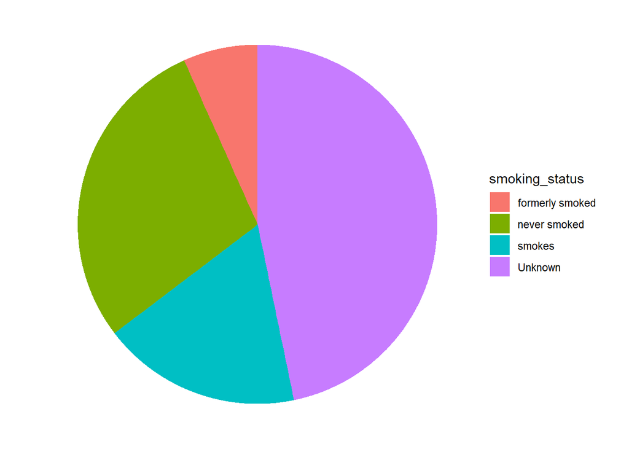

*ANS- Here, this plot illustrate the status of smoking by occupying the position of four smoking status.*

| **Question 3: Create a plot of heart disease & Ever married?** |
| --- |

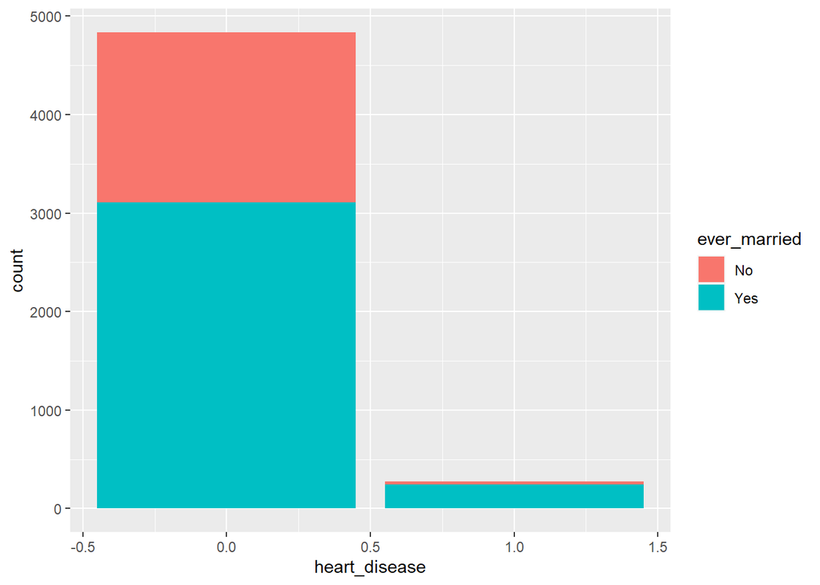

*ANS:- Here, the analysis shows the count of heart disease per ever married person*

| **Question 4: Create an appropriate plot to visualize the distribution of numeric variable.?** |
| --- |

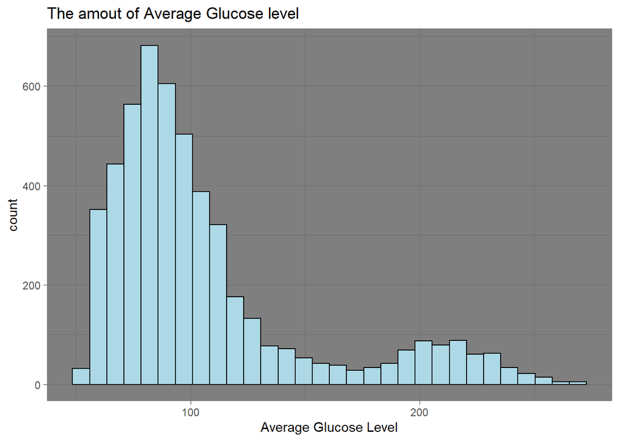

*ANS:- The above plot consist of ability to show the count of various average glucose level.*

| **Question 5: Create an appropriate plot to visualize the proportion of categorical variable.?** |
| --- |

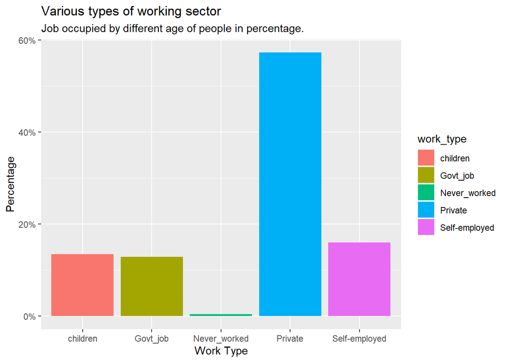

*ANS:- The above plot shows the different work options done by various age of people in percentage.*

| **Question 6: Create an appropriate plot to visualize the relationship between the two numeric variables.?** |
| --- |

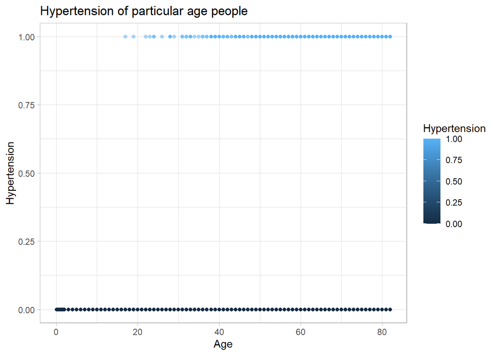

*ANS:- The above chart shows the analysis of Hypertension count of specific age people in health care stroke data set.*

| **Question 7: Create an appropriate plot to visualize the relationship between the numeric and categorical variables.?** |
| --- |

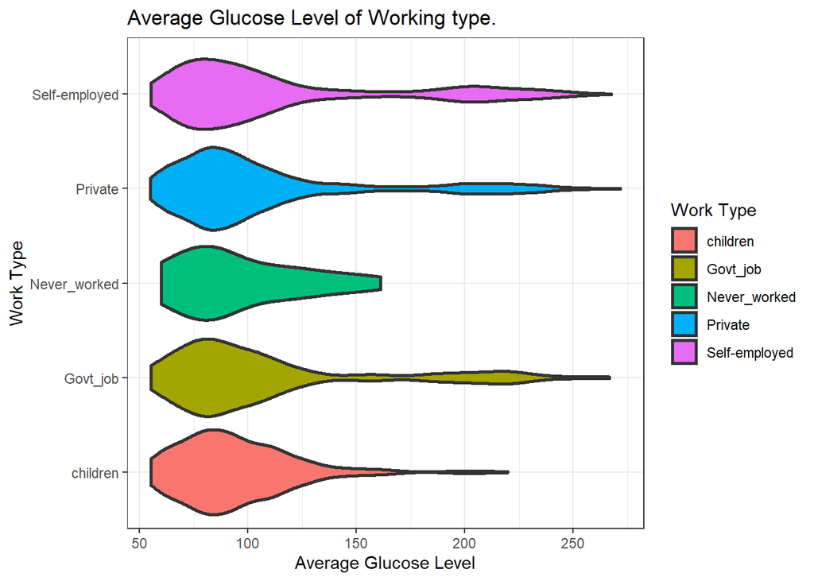

*ANS:- The above plot contains information about average glucose level of various working type people.*

| **Question 8: Choose and calculate an appropriate measure of central tendency.** |
| --- |

```
## [1] 0.05401174
```

*ANS:- The central tendency of heart_disease is 0.05401174*

| **Question 9: Choose an appropriate method to calculate spread of any variable.?** |
| --- |

```
## [1] 22.61265
```

*ANS:- The standard deviation of age is 22.61265*

| **Question 10: How to find unique values of any variable.?** |
| --- |

```
## [1] 1 0
```

*ANS:- The unique value of stroke is 1 or 0*

| *CONCLUSION* |
| --- |

*2) According to this, I have made 10 various question and given the proper answer by generating the different plots like numerical & categorical. Moreover, this data consist of both numerical and categorical data. As, it is required to have various variety of data to clarify any data set in proper manner.*

*4) Furthermore, I had also done the data cleaning to remove the NA values from the dataset as it remove some of the rows from the dataset.*